# Auckland traffic: vehicle types observed on my daily commutes

## Introduction

I conducted an observational survey during each of my daily commutes. I recorded the type of car in front of me at the first traffic light I stopped at. The types of cars include sedans, SUVs, vans etc. I also recorded the license plate of each car, then I used Carjam to determine the age of the cars.

## Car Type Distribution

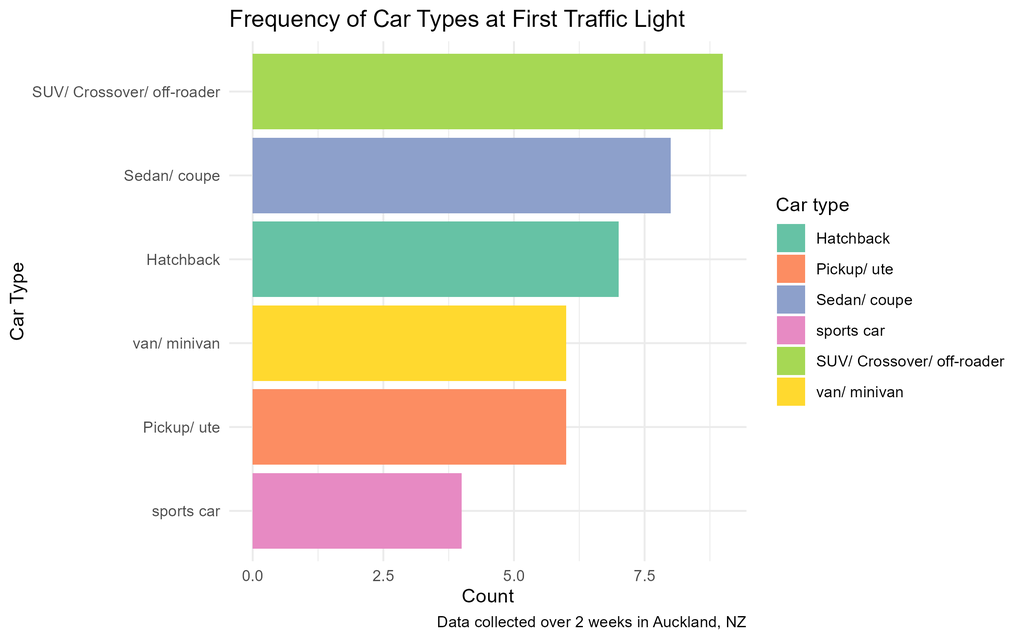

This plot shows the distribution of different vehicle types I have observed. We can see that the most common types of cars are SUV/ Crossover/ Off-roader vehicles. This is not surprising as a report from greenspace.org shows that SUVs make up 53% of new vehicles sold in New Zealand. Sedan/ coupe and hatchbacks follow in second and third place, sports cars are the least common from my observations.

## Vehicle age by type

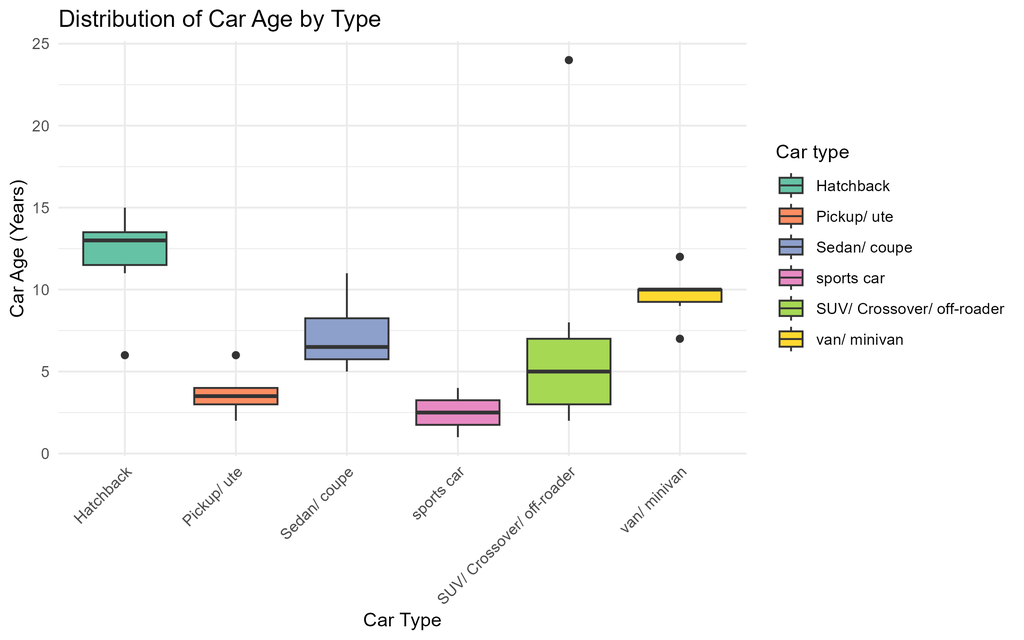

**Is there a relationship between vehicle type and age?** From the plot we can see a box representing the interquartile range, with a thicker line inside showing the median. Hatchbacks and vans/minivans are often older while SUVs and sports cars are often newer. This could reflect the economic choices made by different drivers.

## Timestamp Manipulation

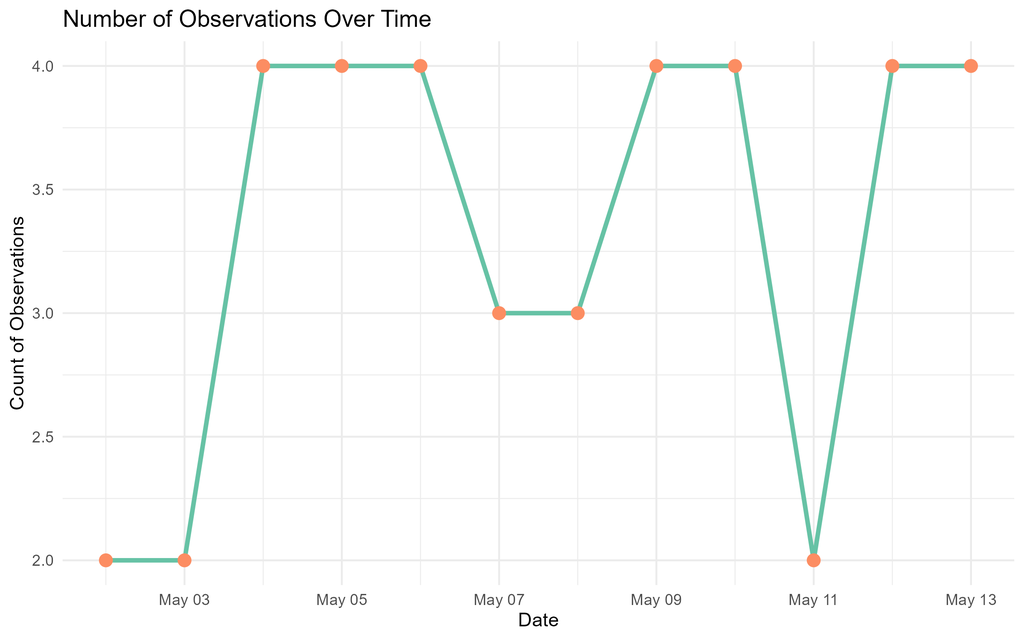

Here is a line graph of the number of cars I have logged per day. The minimum car logged per day is two, this is because everyday I drive to Uni and drive back, resulting in two trips. The days where I have recorded more than two is due to having more trips such as getting food or going to meet with friends.

[github URL](https://zmc2025.github.io/stats220/visual_data_story.html)